# Campus Drink Habits at the University of Auckland

## Introduction

Drinks are a visible part of everyday student life at the University of Auckland. This visual data story explores observational data about drinks carried by people on campus, including drink type, temperature, time of day, and whether the drink container was reusable or disposable.

## What drinks are most common?

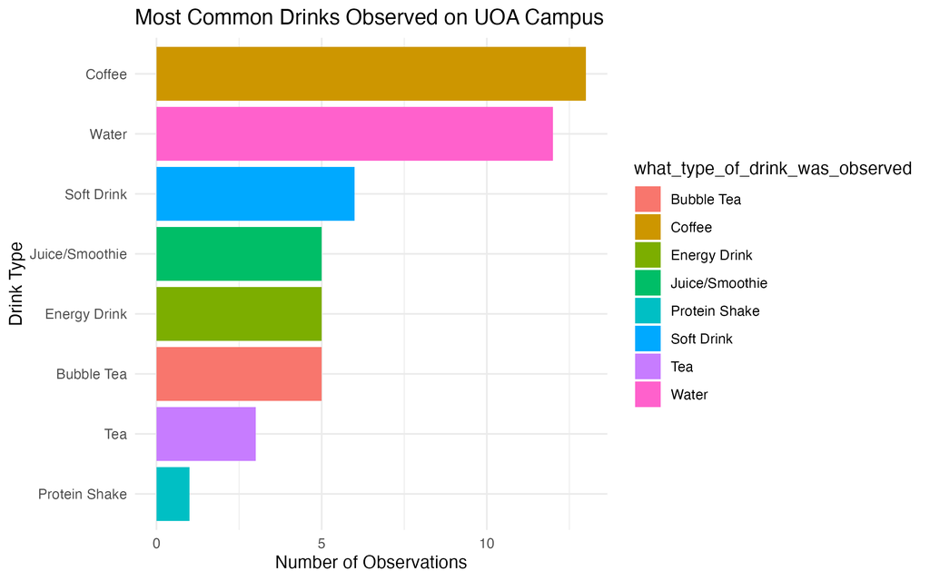

Bar chart showing drink types

This visualisation introduces the overall drink patterns observed on campus by showing which drinks were observed most often. Coffee appeared frequently, reflecting how common takeaway hot drinks are in student routines, while water was also commonly observed as an everyday practical choice.

## How do drink choices change across the day?

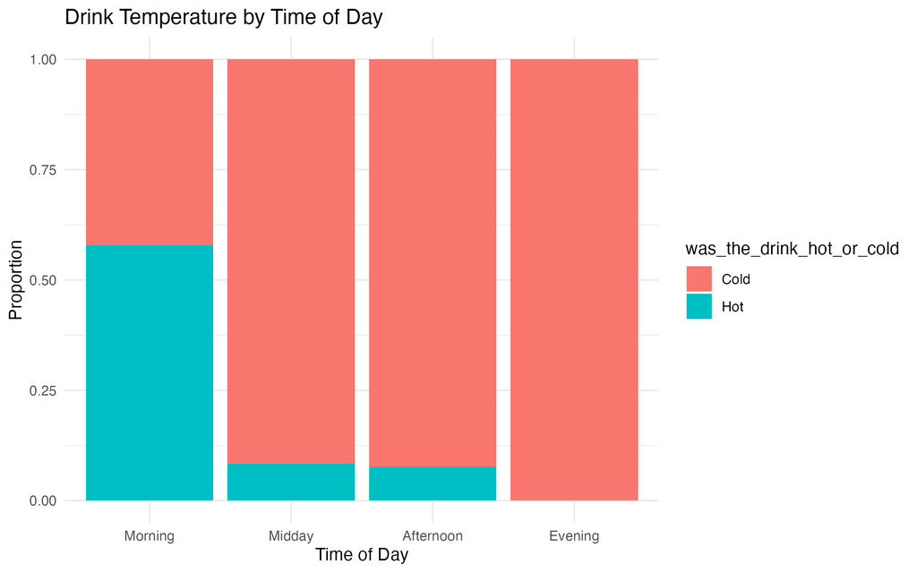

Hot and cold drinks chart

This visualisation compares hot and cold drinks across different times of day. Hot drinks appeared more frequently in morning observations, which aligns with morning study and lecture routines, while colder drinks became more visible later. This helps show how daily habits shape drink choices.

## Reusable or disposable?

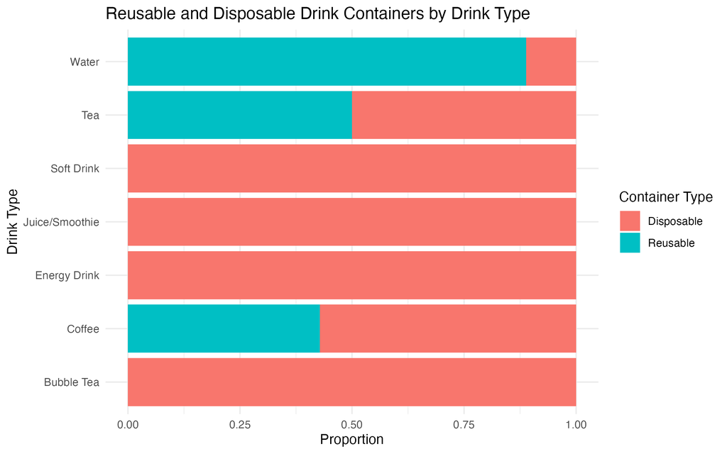

Container type chart

This visualisation adds a sustainability perspective by comparing reusable and disposable containers across drink types. Water was more commonly observed in reusable bottles, while drinks such as coffee and bubble tea appeared more frequently in disposable containers. This suggests that convenience and drink type may influence environmentally related choices.

## Conclusion

Overall, the observations suggest that campus drink habits are shaped by convenience, daily routines, and sustainability choices. Looking at drink type, time of day, and container type together creates a clearer picture of beverage culture on campus.